# Optimal Treatment Analysis

## Outcome Variable

**Outcome Variable:** haz

## Predictor Variables

**Intervention Variable:** single

**Adjustment Set:**

- arm
- W_mage
- meducyrs
- feducyrs
- W_mhtcm
- W_mwtkg
- W_mbmi
- delta_W_mage
- delta_meducyrs
- delta_feducyrs
- delta_W_mhtcm
- delta_W_mwtkg
- delta_W_mbmi

## Stratifying Variables

The analysis was stratified on these variable(s):

- agecat
- studyid
- country

## Data Summary

| agecat | studyid | country | single | n_cell | n |
| --- | --- | --- | --- | --- | --- |
| Birth | ki0047075b-MAL-ED | BANGLADESH | 0 | 231 | 231 |
| Birth | ki0047075b-MAL-ED | BANGLADESH | 1 | 0 | 231 |
| Birth | ki0047075b-MAL-ED | BRAZIL | 0 | 57 | 65 |
| Birth | ki0047075b-MAL-ED | BRAZIL | 1 | 8 | 65 |
| Birth | ki0047075b-MAL-ED | INDIA | 0 | 47 | 47 |
| Birth | ki0047075b-MAL-ED | INDIA | 1 | 0 | 47 |
| Birth | ki0047075b-MAL-ED | NEPAL | 0 | 27 | 27 |
| Birth | ki0047075b-MAL-ED | NEPAL | 1 | 0 | 27 |
| Birth | ki0047075b-MAL-ED | PERU | 0 | 209 | 233 |
| Birth | ki0047075b-MAL-ED | PERU | 1 | 24 | 233 |
| Birth | ki0047075b-MAL-ED | SOUTH AFRICA | 0 | 63 | 123 |
| Birth | ki0047075b-MAL-ED | SOUTH AFRICA | 1 | 60 | 123 |
| Birth | ki0047075b-MAL-ED | TANZANIA, UNITED REPUBLIC OF | 0 | 122 | 125 |
| Birth | ki0047075b-MAL-ED | TANZANIA, UNITED REPUBLIC OF | 1 | 3 | 125 |
| Birth | ki1119695-PROBIT | BELARUS | 0 | 13348 | 13890 |
| Birth | ki1119695-PROBIT | BELARUS | 1 | 542 | 13890 |
| Birth | ki1126311-ZVITAMBO | ZIMBABWE | 0 | 12942 | 13817 |
| Birth | ki1126311-ZVITAMBO | ZIMBABWE | 1 | 875 | 13817 |
| Birth | ki1135781-COHORTS | GUATEMALA | 0 | 719 | 767 |
| Birth | ki1135781-COHORTS | GUATEMALA | 1 | 48 | 767 |
| Birth | ki1135781-COHORTS | INDIA | 0 | 4771 | 4778 |
| Birth | ki1135781-COHORTS | INDIA | 1 | 7 | 4778 |
| Birth | ki1135781-COHORTS | PHILIPPINES | 0 | 2936 | 3010 |
| Birth | ki1135781-COHORTS | PHILIPPINES | 1 | 74 | 3010 |
| Birth | kiGH5241-JiVitA-4 | BANGLADESH | 0 | 2814 | 2819 |
| Birth | kiGH5241-JiVitA-4 | BANGLADESH | 1 | 5 | 2819 |
| 6 months | ki0047075b-MAL-ED | BANGLADESH | 0 | 241 | 241 |
| 6 months | ki0047075b-MAL-ED | BANGLADESH | 1 | 0 | 241 |
| 6 months | ki0047075b-MAL-ED | BRAZIL | 0 | 179 | 209 |
| 6 months | ki0047075b-MAL-ED | BRAZIL | 1 | 30 | 209 |

[output cut: 54 more lines]

The following strata were considered:

- agecat: 24 months, studyid: ki0047075b-MAL-ED, country: BANGLADESH
- agecat: 24 months, studyid: ki0047075b-MAL-ED, country: BRAZIL
- agecat: 24 months, studyid: ki0047075b-MAL-ED, country: INDIA
- agecat: 24 months, studyid: ki0047075b-MAL-ED, country: NEPAL
- agecat: 24 months, studyid: ki0047075b-MAL-ED, country: PERU
- agecat: 24 months, studyid: ki0047075b-MAL-ED, country: SOUTH AFRICA
- agecat: 24 months, studyid: ki0047075b-MAL-ED, country: TANZANIA, UNITED REPUBLIC OF
- agecat: 24 months, studyid: ki1066203-TanzaniaChild2, country: TANZANIA, UNITED REPUBLIC OF
- agecat: 24 months, studyid: ki1119695-PROBIT, country: BELARUS
- agecat: 24 months, studyid: ki1126311-ZVITAMBO, country: ZIMBABWE
- agecat: 24 months, studyid: ki1135781-COHORTS, country: GUATEMALA
- agecat: 24 months, studyid: ki1135781-COHORTS, country: INDIA
- agecat: 24 months, studyid: ki1135781-COHORTS, country: PHILIPPINES
- agecat: 24 months, studyid: kiGH5241-JiVitA-4, country: BANGLADESH
- agecat: 6 months, studyid: ki0047075b-MAL-ED, country: BANGLADESH
- agecat: 6 months, studyid: ki0047075b-MAL-ED, country: BRAZIL
- agecat: 6 months, studyid: ki0047075b-MAL-ED, country: INDIA
- agecat: 6 months, studyid: ki0047075b-MAL-ED, country: NEPAL
- agecat: 6 months, studyid: ki0047075b-MAL-ED, country: PERU
- agecat: 6 months, studyid: ki0047075b-MAL-ED, country: SOUTH AFRICA
- agecat: 6 months, studyid: ki0047075b-MAL-ED, country: TANZANIA, UNITED REPUBLIC OF
- agecat: 6 months, studyid: ki1066203-TanzaniaChild2, country: TANZANIA, UNITED REPUBLIC OF
- agecat: 6 months, studyid: ki1112895-Guatemala BSC, country: GUATEMALA
- agecat: 6 months, studyid: ki1119695-PROBIT, country: BELARUS
- agecat: 6 months, studyid: ki1126311-ZVITAMBO, country: ZIMBABWE
- agecat: 6 months, studyid: ki1135781-COHORTS, country: GUATEMALA
- agecat: 6 months, studyid: ki1135781-COHORTS, country: INDIA
- agecat: 6 months, studyid: ki1135781-COHORTS, country: PHILIPPINES
- agecat: 6 months, studyid: kiGH5241-JiVitA-4, country: BANGLADESH
- agecat: Birth, studyid: ki0047075b-MAL-ED, country: BANGLADESH
- agecat: Birth, studyid: ki0047075b-MAL-ED, country: BRAZIL
- agecat: Birth, studyid: ki0047075b-MAL-ED, country: INDIA
- agecat: Birth, studyid: ki0047075b-MAL-ED, country: NEPAL
- agecat: Birth, studyid: ki0047075b-MAL-ED, country: PERU
- agecat: Birth, studyid: ki0047075b-MAL-ED, country: SOUTH AFRICA
- agecat: Birth, studyid: ki0047075b-MAL-ED, country: TANZANIA, UNITED REPUBLIC OF
- agecat: Birth, studyid: ki1119695-PROBIT, country: BELARUS
- agecat: Birth, studyid: ki1126311-ZVITAMBO, country: ZIMBABWE
- agecat: Birth, studyid: ki1135781-COHORTS, country: GUATEMALA
- agecat: Birth, studyid: ki1135781-COHORTS, country: INDIA
- agecat: Birth, studyid: ki1135781-COHORTS, country: PHILIPPINES
- agecat: Birth, studyid: kiGH5241-JiVitA-4, country: BANGLADESH

### Dropped Strata

Some strata were dropped due to rare outcomes:

- agecat: Birth, studyid: ki0047075b-MAL-ED, country: BANGLADESH
- agecat: Birth, studyid: ki0047075b-MAL-ED, country: INDIA
- agecat: Birth, studyid: ki0047075b-MAL-ED, country: NEPAL
- agecat: Birth, studyid: ki0047075b-MAL-ED, country: TANZANIA, UNITED REPUBLIC OF
- agecat: 6 months, studyid: ki0047075b-MAL-ED, country: BANGLADESH
- agecat: 6 months, studyid: ki0047075b-MAL-ED, country: INDIA
- agecat: 6 months, studyid: ki0047075b-MAL-ED, country: NEPAL
- agecat: 24 months, studyid: ki0047075b-MAL-ED, country: BANGLADESH
- agecat: 24 months, studyid: ki0047075b-MAL-ED, country: INDIA
- agecat: 24 months, studyid: ki0047075b-MAL-ED, country: NEPAL
- agecat: 24 months, studyid: ki1066203-TanzaniaChild2, country: TANZANIA, UNITED REPUBLIC OF

## Methods Detail

We’re interested in the causal parameters $E[Y_a]$ for all values of $a \in \mathcal{A}$. These parameters represent the mean outcome if, possibly contrary to fact, we intervened to set all units to have $A=a$. Under the randomization and positivity assumptions, these are identified by the statistical parameters $\psi_a=E_W[E_{Y|A,W}(Y|A=a,W)]$. In addition, we’re interested in the mean of $Y$, $E[Y]$ under no intervention (the observed mean). We will estimate these parameters by using SuperLearner to fit the relevant likelihood factors – $E_{Y|A,W}(Y|A=a,W)$ and $p(A=a|W)$, and then updating our likelihood fit using a joint TMLE.

For unadjusted analyses ($W=\{\}$), initial likelihoods were estimated using Lrnr_glm to estimate the simple $E(Y|A)$ and Lrnr_mean to estimate $p(A)$. For adjusted analyses, a small library containing Lrnr_glmnet, Lrnr_xgboost, and Lrnr_mean was used.

Having estimated these parameters, we will then use the delta method to estimate relative risks and attributable risks relative to a prespecified baseline level of $A$.

# Results Detail

## Results Plots

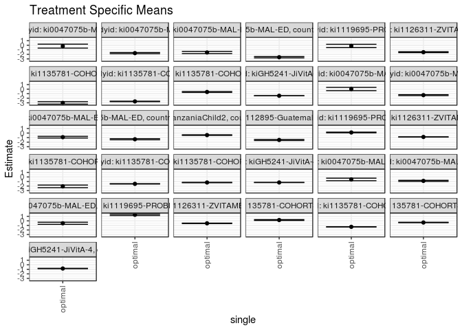

## Results Table

### Parameter: TSM

| agecat | studyid | country | intervention_level | baseline_level | estimate | ci_lower | ci_upper |
| --- | --- | --- | --- | --- | --- | --- | --- |
| Birth | ki0047075b-MAL-ED | BRAZIL | optimal | observed | -0.5438747 | -0.8250208 | -0.2627286 |
| Birth | ki0047075b-MAL-ED | PERU | optimal | observed | -0.8650944 | -0.9860571 | -0.7441318 |
| Birth | ki0047075b-MAL-ED | SOUTH AFRICA | optimal | observed | -0.5309834 | -0.7623812 | -0.2995857 |
| Birth | ki1119695-PROBIT | BELARUS | optimal | observed | 1.3361160 | 1.1736928 | 1.4985392 |
| Birth | ki1126311-ZVITAMBO | ZIMBABWE | optimal | observed | -0.5396643 | -0.5855678 | -0.4937609 |
| Birth | ki1135781-COHORTS | GUATEMALA | optimal | observed | 0.1819531 | 0.0923015 | 0.2716046 |
| Birth | ki1135781-COHORTS | INDIA | optimal | observed | -1.3131295 | -1.3329389 | -1.2933202 |
| Birth | ki1135781-COHORTS | PHILIPPINES | optimal | observed | -0.3630938 | -0.4113969 | -0.3147907 |
| Birth | kiGH5241-JiVitA-4 | BANGLADESH | optimal | observed | -0.8256141 | -0.8614905 | -0.7897377 |
| 6 months | ki0047075b-MAL-ED | BRAZIL | optimal | observed | 0.0311521 | -0.3258275 | 0.3881318 |
| 6 months | ki0047075b-MAL-ED | PERU | optimal | observed | -1.3136791 | -1.4266598 | -1.2006984 |
| 6 months | ki0047075b-MAL-ED | SOUTH AFRICA | optimal | observed | -0.9050084 | -1.0872621 | -0.7227546 |
| 6 months | ki0047075b-MAL-ED | TANZANIA, UNITED REPUBLIC OF | optimal | observed | -1.3623439 | -1.4876194 | -1.2370685 |
| 6 months | ki1066203-TanzaniaChild2 | TANZANIA, UNITED REPUBLIC OF | optimal | observed | -0.4498372 | -0.5171111 | -0.3825633 |
| 6 months | ki1112895-Guatemala BSC | GUATEMALA | optimal | observed | -1.5179170 | -1.6404335 | -1.3954006 |
| 6 months | ki1119695-PROBIT | BELARUS | optimal | observed | 0.1253036 | 0.0464311 | 0.2041762 |
| 6 months | ki1126311-ZVITAMBO | ZIMBABWE | optimal | observed | -0.8571103 | -0.8834043 | -0.8308162 |
| 6 months | ki1135781-COHORTS | GUATEMALA | optimal | observed | -2.0648213 | -2.3508988 | -1.7787437 |
| 6 months | ki1135781-COHORTS | INDIA | optimal | observed | -1.5151918 | -1.5516594 | -1.4787242 |
| 6 months | ki1135781-COHORTS | PHILIPPINES | optimal | observed | -1.2164637 | -1.2588951 | -1.1740323 |
| 6 months | kiGH5241-JiVitA-4 | BANGLADESH | optimal | observed | -1.2108524 | -1.2357653 | -1.1859395 |
| 24 months | ki0047075b-MAL-ED | BRAZIL | optimal | observed | -0.1975882 | -0.6312858 | 0.2361094 |
| 24 months | ki0047075b-MAL-ED | PERU | optimal | observed | -1.7334433 | -1.8596527 | -1.6072339 |
| 24 months | ki0047075b-MAL-ED | SOUTH AFRICA | optimal | observed | -1.5842836 | -1.8261760 | -1.3423912 |
| 24 months | ki0047075b-MAL-ED | TANZANIA, UNITED REPUBLIC OF | optimal | observed | -2.6330003 | -2.7706728 | -2.4953278 |
| 24 months | ki1119695-PROBIT | BELARUS | optimal | observed | -0.1584853 | -0.5215603 | 0.2045898 |
| 24 months | ki1126311-ZVITAMBO | ZIMBABWE | optimal | observed | -1.5260135 | -1.6230918 | -1.4289353 |
| 24 months | ki1135781-COHORTS | GUATEMALA | optimal | observed | -3.0213900 | -3.2881209 | -2.7546591 |
| 24 months | ki1135781-COHORTS | INDIA | optimal | observed | -2.6951037 | -2.7428563 | -2.6473510 |
| 24 months | ki1135781-COHORTS | PHILIPPINES | optimal | observed | -0.6199067 | -0.7211784 | -0.5186349 |
| 24 months | kiGH5241-JiVitA-4 | BANGLADESH | optimal | observed | -1.4518481 | -1.4638172 | -1.4398790 |

### Parameter: E(Y)

| agecat | studyid | country | intervention_level | baseline_level | estimate | ci_lower | ci_upper |
| --- | --- | --- | --- | --- | --- | --- | --- |
| Birth | ki0047075b-MAL-ED | BRAZIL | observed | observed | -0.6760000 | -0.9521457 | -0.3998543 |
| Birth | ki0047075b-MAL-ED | PERU | observed | observed | -0.8827897 | -1.0001058 | -0.7654736 |
| Birth | ki0047075b-MAL-ED | SOUTH AFRICA | observed | observed | -0.6317073 | -0.8249555 | -0.4384591 |
| Birth | ki1119695-PROBIT | BELARUS | observed | observed | 1.3269446 | 1.1683850 | 1.4855041 |
| Birth | ki1126311-ZVITAMBO | ZIMBABWE | observed | observed | -0.5007838 | -0.5213479 | -0.4802197 |
| Birth | ki1135781-COHORTS | GUATEMALA | observed | observed | 0.1511213 | 0.0632481 | 0.2389944 |
| Birth | ki1135781-COHORTS | INDIA | observed | observed | -0.6774424 | -0.7103357 | -0.6445492 |
| Birth | ki1135781-COHORTS | PHILIPPINES | observed | observed | -0.2465548 | -0.2856502 | -0.2074594 |
| Birth | kiGH5241-JiVitA-4 | BANGLADESH | observed | observed | -1.5236006 | -1.5727441 | -1.4744571 |
| 6 months | ki0047075b-MAL-ED | BRAZIL | observed | observed | 0.0510207 | -0.0930194 | 0.1950608 |
| 6 months | ki0047075b-MAL-ED | PERU | observed | observed | -1.3280952 | -1.4363364 | -1.2198541 |
| 6 months | ki0047075b-MAL-ED | SOUTH AFRICA | observed | observed | -1.0639173 | -1.1916078 | -0.9362269 |
| 6 months | ki0047075b-MAL-ED | TANZANIA, UNITED REPUBLIC OF | observed | observed | -1.3687449 | -1.4907629 | -1.2467270 |
| 6 months | ki1066203-TanzaniaChild2 | TANZANIA, UNITED REPUBLIC OF | observed | observed | -0.5457721 | -0.5948454 | -0.4966988 |
| 6 months | ki1112895-Guatemala BSC | GUATEMALA | observed | observed | -1.5624368 | -1.6783540 | -1.4465196 |
| 6 months | ki1119695-PROBIT | BELARUS | observed | observed | 0.1069986 | 0.0122286 | 0.2017686 |
| 6 months | ki1126311-ZVITAMBO | ZIMBABWE | observed | observed | -0.8677917 | -0.8934036 | -0.8421799 |
| 6 months | ki1135781-COHORTS | GUATEMALA | observed | observed | -1.8089474 | -1.8800645 | -1.7378303 |
| 6 months | ki1135781-COHORTS | INDIA | observed | observed | -1.0418789 | -1.0745363 | -1.0092215 |
| 6 months | ki1135781-COHORTS | PHILIPPINES | observed | observed | -1.1414425 | -1.1836656 | -1.0992193 |
| 6 months | kiGH5241-JiVitA-4 | BANGLADESH | observed | observed | -1.3441456 | -1.3814027 | -1.3068885 |
| 24 months | ki0047075b-MAL-ED | BRAZIL | observed | observed | 0.0071006 | -0.1615817 | 0.1757828 |
| 24 months | ki0047075b-MAL-ED | PERU | observed | observed | -1.7544776 | -1.8753255 | -1.6336298 |
| 24 months | ki0047075b-MAL-ED | SOUTH AFRICA | observed | observed | -1.6491807 | -1.7842885 | -1.5140729 |
| 24 months | ki0047075b-MAL-ED | TANZANIA, UNITED REPUBLIC OF | observed | observed | -2.6451636 | -2.7802323 | -2.5100948 |
| 24 months | ki1119695-PROBIT | BELARUS | observed | observed | -0.1314048 | -0.4282725 | 0.1654630 |
| 24 months | ki1126311-ZVITAMBO | ZIMBABWE | observed | observed | -1.6034545 | -1.6603071 | -1.5466018 |
| 24 months | ki1135781-COHORTS | GUATEMALA | observed | observed | -2.9960594 | -3.0622330 | -2.9298858 |
| 24 months | ki1135781-COHORTS | INDIA | observed | observed | -2.2131442 | -2.2522996 | -2.1739887 |
| 24 months | ki1135781-COHORTS | PHILIPPINES | observed | observed | -2.4207616 | -2.4660144 | -2.3755087 |
| 24 months | kiGH5241-JiVitA-4 | BANGLADESH | observed | observed | -1.7811362 | -1.8166519 | -1.7456205 |

### Parameter: PAR

| agecat | studyid | country | intervention_level | baseline_level | estimate | ci_lower | ci_upper |
| --- | --- | --- | --- | --- | --- | --- | --- |
| Birth | ki0047075b-MAL-ED | BRAZIL | optimal | observed | -0.1321253 | -0.2642969 | 0.0000463 |
| Birth | ki0047075b-MAL-ED | PERU | optimal | observed | -0.0176953 | -0.0622340 | 0.0268434 |
| Birth | ki0047075b-MAL-ED | SOUTH AFRICA | optimal | observed | -0.1007239 | -0.3079029 | 0.1064551 |
| Birth | ki1119695-PROBIT | BELARUS | optimal | observed | -0.0091714 | -0.0274375 | 0.0090947 |
| Birth | ki1126311-ZVITAMBO | ZIMBABWE | optimal | observed | 0.0388805 | -0.0019346 | 0.0796956 |
| Birth | ki1135781-COHORTS | GUATEMALA | optimal | observed | -0.0308318 | -0.0560970 | -0.0055666 |
| Birth | ki1135781-COHORTS | INDIA | optimal | observed | 0.6356871 | 0.6006076 | 0.6707666 |
| Birth | ki1135781-COHORTS | PHILIPPINES | optimal | observed | 0.1165390 | 0.0655847 | 0.1674933 |
| Birth | kiGH5241-JiVitA-4 | BANGLADESH | optimal | observed | -0.6979865 | -0.7577723 | -0.6382006 |
| 6 months | ki0047075b-MAL-ED | BRAZIL | optimal | observed | 0.0198686 | -0.2812713 | 0.3210085 |
| 6 months | ki0047075b-MAL-ED | PERU | optimal | observed | -0.0144161 | -0.0579624 | 0.0291301 |
| 6 months | ki0047075b-MAL-ED | SOUTH AFRICA | optimal | observed | -0.1589089 | -0.3161008 | -0.0017170 |
| 6 months | ki0047075b-MAL-ED | TANZANIA, UNITED REPUBLIC OF | optimal | observed | -0.0064010 | -0.0204874 | 0.0076855 |
| 6 months | ki1066203-TanzaniaChild2 | TANZANIA, UNITED REPUBLIC OF | optimal | observed | -0.0959349 | -0.1577277 | -0.0341421 |
| 6 months | ki1112895-Guatemala BSC | GUATEMALA | optimal | observed | -0.0445198 | -0.0847618 | -0.0042778 |
| 6 months | ki1119695-PROBIT | BELARUS | optimal | observed | -0.0183050 | -0.0816258 | 0.0450157 |
| 6 months | ki1126311-ZVITAMBO | ZIMBABWE | optimal | observed | -0.0106815 | -0.0174982 | -0.0038647 |
| 6 months | ki1135781-COHORTS | GUATEMALA | optimal | observed | 0.2558739 | -0.0148733 | 0.5266211 |
| 6 months | ki1135781-COHORTS | INDIA | optimal | observed | 0.4733129 | 0.4297952 | 0.5168307 |
| 6 months | ki1135781-COHORTS | PHILIPPINES | optimal | observed | 0.0750213 | 0.0221589 | 0.1278836 |
| 6 months | kiGH5241-JiVitA-4 | BANGLADESH | optimal | observed | -0.1332932 | -0.1774835 | -0.0891028 |
| 24 months | ki0047075b-MAL-ED | BRAZIL | optimal | observed | 0.2046888 | -0.1946908 | 0.6040684 |
| 24 months | ki0047075b-MAL-ED | PERU | optimal | observed | -0.0210343 | -0.0742025 | 0.0321339 |
| 24 months | ki0047075b-MAL-ED | SOUTH AFRICA | optimal | observed | -0.0648970 | -0.2705917 | 0.1407977 |
| 24 months | ki0047075b-MAL-ED | TANZANIA, UNITED REPUBLIC OF | optimal | observed | -0.0121632 | -0.0317268 | 0.0074003 |
| 24 months | ki1119695-PROBIT | BELARUS | optimal | observed | 0.0270805 | -0.3091996 | 0.3633606 |
| 24 months | ki1126311-ZVITAMBO | ZIMBABWE | optimal | observed | -0.0774410 | -0.1595205 | 0.0046385 |
| 24 months | ki1135781-COHORTS | GUATEMALA | optimal | observed | 0.0253306 | -0.2288839 | 0.2795451 |
| 24 months | ki1135781-COHORTS | INDIA | optimal | observed | 0.4819595 | 0.4264507 | 0.5374683 |
| 24 months | ki1135781-COHORTS | PHILIPPINES | optimal | observed | -1.8008549 | -1.9116015 | -1.6901084 |
| 24 months | kiGH5241-JiVitA-4 | BANGLADESH | optimal | observed | -0.3292880 | -0.3661868 | -0.2923893 |